# Raport HW3

Paweł Baćmaga, Robert Jankowski

Warszawa, 28 marca 2023

# Wstęp

W raporcie przedstawimy rezultat badania czytelności wykresów przeprowadzonego na próbie 15 osób niezwiązanych na co dzień z zagadnieniami analizy danych.  
Nasze badanie polegało na dwóch eksperymentach, w których sprawdziliśmy, na ile poprawnie nasi ankietowani odczytują dane z różnych form wizualizacji przedstawiajacych dokładnie te same dane.

# Badania

## Eksperyment 1 - Star Wars

W tym eksperymencie utworzyliśmy dwa wykresy przedstawiające procentowy rozkład występowania różnych kolorów oczu u postaci z serii *Star Wars* na podstawie ramki danych starwars, która używana była na zajęciach laboratoryjnych.

Pierwszy wykres to trójwymiarowy wykres kołowy, na którym to nie zamieściliśmy jednak dokładnych wartości procentowych w formie etykiet.  
Następnie zapytaliśmy ankietowanych, aby odpowiedzieli na dwa pytania:

- Który kolor oczu występuje najczęściej? (do wyboru brązowy lub niebieski)
- Który kolor występuje częściej: Żółty czy Czarny?

Następnie stworzyliśmy wykres słupkowy przedstawiający te same dane z podanymi dokładnymi wartościami i etykietami, ale bez kolorów. Stworzona została także jego wersja, w której każdy ze słupków został pokolorowany na kolor odpowiadający kolorowi oczu, który reprezentuje, ale bez etykiet.  
Zapytaliśmy uczestników eksperymentu o to:

- Który wykres jest łatwiejszy w interpretacji?
- Który wykres jest bardziej estetyczny?

Na sam koniec zadaliśmy pytanie, który z wykresów, trójwymiarowy kołowy czy prosty słupkowy ze skalą, bez dokładnych wartości, jest ogólnie “lepszy”. Poniżej znajduje się tabela z wynikami naszego badania:

Tabela z wynikami eksperymentu nr 1

| Osoba | Najczęstszy kolor? | Żółty czy czarny jest częściej? | Który wykres łatwiej interpretować? | Który wykres jest bardziej estetyczny? | Który wykres jest lepszy? |
| --- | --- | --- | --- | --- | --- |
| 1 | brazowy | zolty | 1 | 1 | 2 |
| 2 | niebieski | zolty | 2 | 2 | 2 |
| 3 | brazowy | zolty | 1 | 1 | 2 |
| 4 | brazowy | czarny | 1 | 2 | 2 |
| 5 | brazowy | zolty | 1 | 1 | 2 |
| 6 | brazowy | czarny | 2 | 2 | 2 |
| 7 | brazowy | zolty | 1 | 2 | 2 |
| 8 | brazowy | zolty | 1 | 1 | 2 |
| 9 | niebieski | zolty | 2 | 2 | 2 |
| 10 | brazowy | zolty | 2 | 2 | 2 |
| 11 | brazowy | zolty | 2 | 2 | 2 |
| 12 | niebieski | zolty | 2 | 2 | 2 |
| 13 | brazowy | zolty | 1 | 2 | 2 |
| 14 | brazowy | zolty | 2 | 2 | 2 |
| 15 | brazowy | czarny | 1 | 1 | 2 |

### Sprawdzenie poprawności odczytania danych z wykresu przez badanych

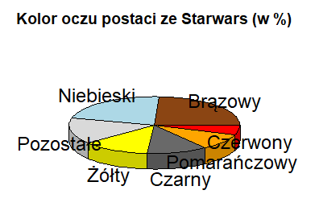

Podsumowanie liczby odpowiedzi na pytanie o najczęstszy kolor oczu

| Odpowiedź | Liczba odpowiedzi |
| --- | --- |
| brazowy | 12 |
| niebieski | 3 |

Jak widzimy większość osób odpowiedziała poprawnie na pytanie o odczytanie z wykresu kołowego najczęściej występującego koloru. 3 osoby odpowiedziały jednakże błędnie wskazując na niebieski kolor jako częstszy.

Odpowiedzi na pytanie który kolor występuje częściej: Żółty czy czarny?

| Odpowiedź | Liczba odpowiedzi |
| --- | --- |
| czarny | 3 |
| zolty | 12 |

Na to pytanie również większość ankietowanych udzieliła prawidłowej odpowiedzi, że żólty występuje częściej niż czarny.  
Znalazły się jednak 3 osoby, które błędnie odczytały dane z wykresu wskazując na kolor czarny jako częstszy.

### Subiektywne opinie na temat wykresów

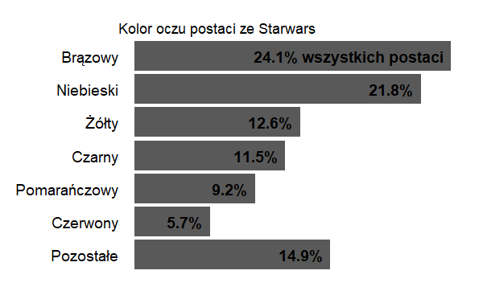

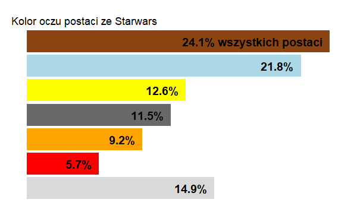

Wykres 1 (po lewej) oraz Wykres 2 (po prawej)

Odpowiedzi na pytanie który wykres łatwiej interpretować

| Odpowiedź | Liczba odpowiedzi |
| --- | --- |
| 1 | 8 |
| 2 | 7 |

Wśrod naszych respondentów zdania są podzielone co do tego, czy wykres słupkowy czarno-biały z etykietami tekstowymi z nazwą koloru czy ten sam wykres, ale z kolorowymi słupkami jest łatwiejszy w interpretacji.

Odpowiedzi na pytanie który wykres jest bardziej estetyczny

| Odpowiedź | Liczba odpowiedzi |
| --- | --- |
| 1 | 5 |
| 2 | 10 |

Jeśli chodzi o to, który jest bardziej estetyczny, to wykres z pokolorowanymi słupkami cieszy się większym uznaniem.

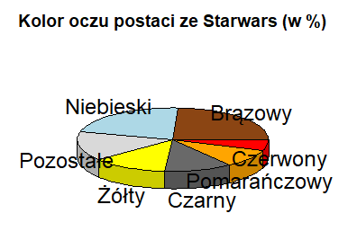

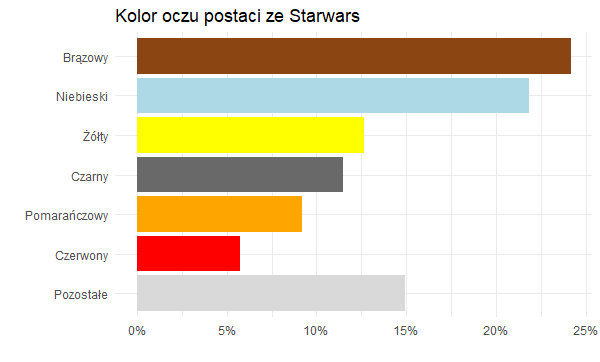

Wykres 1 (po lewej) oraz Wykres 2 (po prawej)

Odpowiedzi na pytanie który wykres jest lepszy

| Odpowiedź | Liczba odpowiedzi |
| --- | --- |
| 2 | 15 |

Wszyscy badani jednoznacznie wskazali, że wykres słupkowy ze skalą jest zdecydowanie lepszą formą przedstawienia danych niż wykres kołowy 3D.

## Eksperyment 2 - Auta

W tym eksperymencie stworzone zostały dwie wizualizacje przedstawiające te same dane na temat samochodów z ramki danych auta2012 z pakietu *PogromcyDanych*.  
Wykresy przedstawiają średnią cenę aut oraz ich średni przebieg dla 10 najpopularniejszych marek.  
Pierwsza wizualizacja została utworzona w programie *Microsoft Excel* i ma ona formę wykresu trójwymiarowego, gdzie pierwszy rząd słupków danych przedstawia średnią cenę, a drugi rząd znajdujący się za nim - średni przebieg. Zarówno wartości liczbowe ceny jak i przebiegu są pokazane na tej samej osi liczbowej.  
Drugi sposób przedstawienia danych został utworzony za pomocą pakietu *ggplot* i składa się z dwóch wykresów słupkowych. Pierwszy z nich przedstawia średnią cenę auta, a drugi średni przebieg dla danej marki.

Uczestnikom eksperymentu zadaliśmy trzy pytania:

- Czy średnia cena Audi jest większa czy mniejsza niż 50000?

  *(Poprawna odpowiedź: większa)*
- Dla ilu marek samochodów średni przebieg w km przekracza 150 tys. km? (Proszę podać liczbę)

  *(Poprawna odpowiedź: 4)*
- Czy wykresy słupkowe trójwymiarowe wprowadzają odbiorcę w błąd?

Tabela z wynikami eksperymentu nr 2

| Osoba | Czy cena Audi jest większa niż 50 tys. na wykresie 1? | Liczba marek dla których przebieg > 150 000 km na wykresie 1? | Czy cena Audi jest większa niż 50 tys. na wykresie 2? | Liczba marek dla których przebieg > 150 000 km na wykresie 2? | Czy wykresy 3D wprowadzają w błąd? |
| --- | --- | --- | --- | --- | --- |
| 1 | False | 2 | True | 4 | True |
| 2 | False | 2 | True | 4 | True |
| 3 | False | 2 | True | 4 | True |
| 4 | False | 3 | True | 4 | True |
| 5 | False | 2 | True | 4 | True |
| 6 | False | 2 | True | 4 | True |
| 7 | False | 2 | True | 4 | True |
| 8 | False | 2 | True | 4 | True |
| 9 | False | 2 | True | 4 | True |
| 10 | False | 2 | True | 4 | True |
| 11 | False | 3 | True | 4 | True |
| 12 | False | 2 | True | 4 | False |
| 13 | False | 2 | True | 4 | True |
| 14 | False | 2 | True | 4 | True |
| 15 | False | 2 | True | 4 | True |

### Pierwsza wizualizacja i poprawność odpowiedzi na jej podstawie

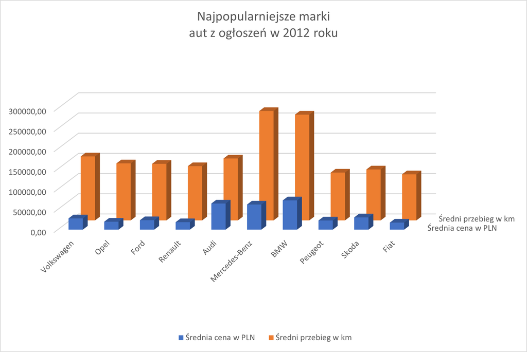

Podsumowanie liczby odpowiedzi na pytanie czy cena Audi jest większa niż 50 000 PLN

| Odpowiedź | Liczba odpowiedzi |
| --- | --- |
| False | 15 |

Wszyscy badani źle odczytali dane i odpowiedzieli, że średnia cena Audi jest mniejsza niż 50 000 PLN.

Podsumowanie liczby odpowiedzi na pytanie dla ilu marek samochodów średni przebieg w km przekracza 150 tys.

| Odpowiedź | Liczba odpowiedzi |
| --- | --- |
| 2 | 13 |
| 3 | 2 |

Na to pytanie również nikt nie wskazał poprawnej odpowiedzi, jaką jest liczba 4.

### Druga wizualizacja i poprawność odpowiedzi na jej podstawie

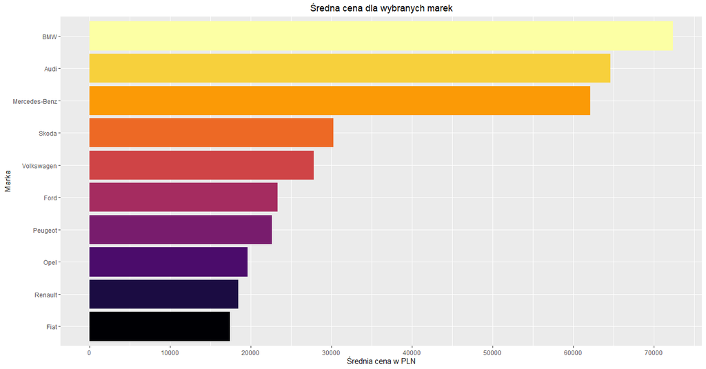

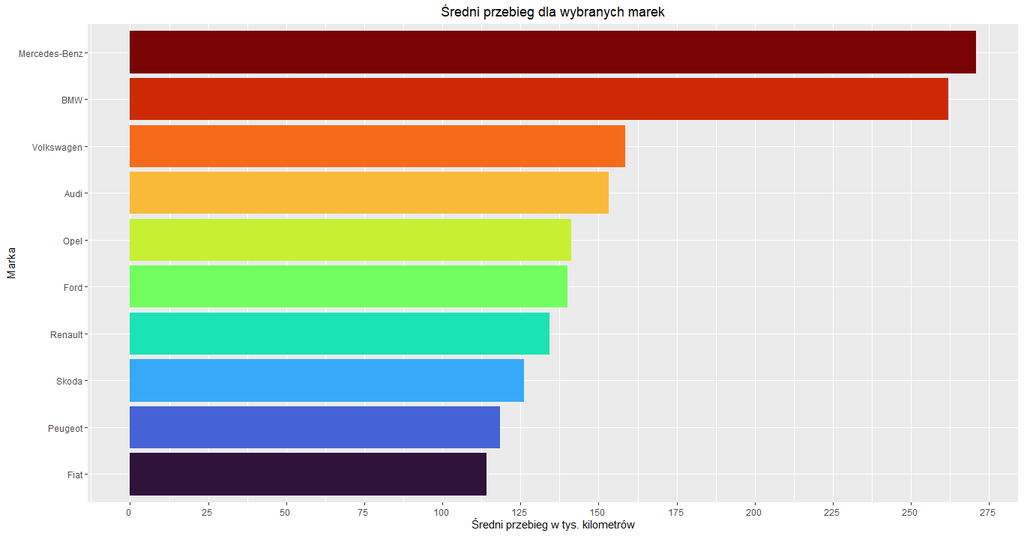

Podsumowanie liczby odpowiedzi na pytanie czy cena Audi jest większa niż 50 000 PLN

| Odpowiedź | Liczba odpowiedzi |
| --- | --- |
| True | 15 |

Tym razem każdy poprawnie odczytał dane dotyczące ceny Audi.

Podsumowanie liczby odpowiedzi na pytanie dla ilu marek samochodów średni przebieg w km przekracza 150 tys.

| Odpowiedź | Liczba odpowiedzi |
| --- | --- |
| 4 | 15 |

Również pytanie dotyczące liczby marek, dla których średni przebieg przekracza 150 000 km nie przysporzyło kłopotów badanych i wszyscy odpowiedzieli prawidłowo.

### Czy wykresy słupkowe trójwymiarowe wprowadzają odbiorcę w błąd?

Podsumowanie liczby odpowiedzi na pytanie czy wykresy słupkowe trójwymiarowe wprowadzają odbiorcę w błąd

| Odpowiedź | Liczba odpowiedzi |
| --- | --- |
| False | 1 |
| True | 14 |

Na to pytanie wyraźna większość ankietowanych odpowiedziała twierdząco.

# Wnioski

Biorąc pod uwagę rezultaty powyższych badań możemy stwierdzić, że aby przedstawić dane w sposób zrozumiały i nie budzący wątpliwości dla odbiorcy, należy unikać wykresów kołowych oraz wykresów trójwymiarowych.  
Niezawodną formą przedstawiania danych okazują się proste wykresy słupkowe i kolumnowe.